# PSET 6 - Quasipoisson, Neg Bin, Bin Log, Bootstrapping, CV, Ridge, Lasso

S&DS 361

Due 2024-04-16

## Maps

### 1. EV charging station locations

```r
d = readRDS('data/EVstations.rds')
colnames(d) = tolower(colnames(d))

d = d %>%
  select(-matches('cng|lng|lpg|hydrogen|e85|bd[.]blends|french|^ng[.]|plus4|level1')) %>%
  filter(fuel.type.code=='ELEC') %>%
  rename(lev2=ev.level2.evse.num,
         lev3=ev.dc.fast.count,
         network = ev.network,
         lat = latitude,
         lon = longitude) %>%
  mutate(status = case_when(status.code=='E' ~ 'avail',
                            status.code=='P' ~ 'planned',
                            status.code=='T' ~ 'temp.unavail',
                            TRUE ~ ''),
         lev2 = ifelse(is.na(lev2), 0, lev2),
         lev3 = ifelse(is.na(lev3), 0, lev3)) %>%
  mutate(network = ifelse(network=='Tesla Destination', 'Tesla', network),
         network = gsub('Ã©', 'E', network),
         network = gsub('Ã‰', 'E', network))
```

Plot the locations of Level 3 Charging Stations and this time make sure we can easily distinguish what network each charging station belongs to. Consider the top 5 networks (Tesla, Electrify America, ChargePoint, eVgo, and Non-Networked) separately and group all other networks together as “Other”.

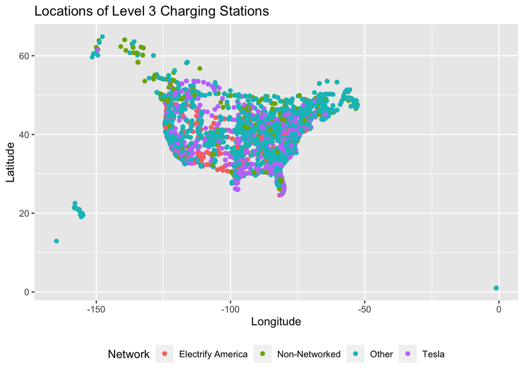

```r
# group all other networks together as "Other"
d = d %>%
  mutate(network = case_when(network %in% c('Tesla', 'Electrify America', 'ChargePoint', 'eVgo', 'Non-Networked') ~ network,
                             TRUE ~ 'Other'))

# filter for points with level 3 charging stations
d1 <- d %>% filter(lev3 > 0)

# locations are determined by longitude (lon) and latitude (lat)
# plotting
g1 <- ggplot(d1, aes(x = lon, y = lat, color = as.factor(network))) +
  geom_point() +
  labs(title = "Locations of Level 3 Charging Stations",
       x = "Longitude",
       y = "Latitude",
       color = "Network") +
  theme(legend.position = "bottom")

g1
```

### 2. Animation

Make a plot like above but facet by network, and animate it using `open.date` as the time variable. Since there are ~1458 unique `open.dates`, we probably don’t want one frame per date. So create a month column and use one frame per month. When a charging station appears, we want it to stay for the rest of the animation (not go away the next month). Upload your `gif` to Gradescope in the assignment denoted “GIF”, and at the end of your code below, include a screenshot of the animation taken sometime halfway through the animation. Tip for knitting your PDF: as discussed in class, comment out your `animate` code after creating a `.gif` so that your document knits more quickly.

**Code**

```r
# create a month column
d1 <- d1 %>%
  mutate(month = format(as.Date(open.date), "%Y-%m"))

# create animation of charging stations, faceted by network

# first create a static plot
g2 <- ggplot(d1, aes(x = lon, y = lat, color = as.factor(network))) +
  geom_point() +
  theme(legend.position = "bottom") +
  facet_wrap(~network)

# then animate the plot
a = g2 +
  transition_states(month) +
  # make sure points stay on the map
  shadow_mark(past = TRUE, future = FALSE) +
  labs(title = "Locations of Level 3 Charging Stations, {closest_state}",
       x = "Longitude",
       y = "Latitude",
       color = "Network")

# anim_save("img/charging_stations.gif", a,
#          duration = 15, width = 800, height = 600)
```

**Screenshot here**

[figure not shown]

### 3. Interactive Plot

Plot EV charging station locations on an interactive map with `leaflet`. Create labels that show the EV network, station name, street address, city, state, zip, and the number Level 2 and Level 3 charging stations. Size the dots by the number of chargers at that location. Since your computer might have issues showing all the points at once, plot just the locations in CT.

```r
# filter for points in CT
d2 <- d %>% filter(state == "CT")

m <- leaflet(d2) %>%
  addTiles() %>%
  addCircleMarkers(lng = ~lon, lat = ~lat,
                   radius = ~(lev2 + lev3),
                   color = "red",
                   popup = ~paste(network, "<br>",
                                  station.name, "<br>",
                                  street.address, "<br>",
                                  city, ", ", state, " ", zip, "<br>",
                                  "Level 2: ", lev2, "<br>",
                                  "Level 3: ", lev3))

m
```

[interactive chart not shown]

## Shiny

### 4. Basic Shiny App

Do the following to create a basic shiny app and publish it to shinyapps.io

- Configure R Studio to communicate with shinyapps.io by following the directions from this page https://shiny.rstudio.com/articles/shinyapps.html up to and including the “Method 1” section. You will show you how to install `rsconnect`, create a shinyapps.io account, and set up communication between R Studio and shinyapps.io. Note that you will only have to do this once.
- Create a new shiny app like we did in class by clicking File, New File, Shiny Web App. Name the app `hw03app1`, choose Single File, choose an appropriate directory, and click Create. An `app.R` file will open in R Studio.
- Click Run App to see the app. The app should appear in the Viewer tab in R Studio, or in its own window.
- In the upper right of the app, click Publish. Make sure the correct files and account are selected. Click Publish in the lower right.

Paste the url for your app here. The url will be of the form https://yourusername.shinyapps.io/yourappname/

**https://lliu58.shinyapps.io/hw03app1/**

### 5. Shiny App for EV Charging Stations

Create a Shiny app that contains a leaflet map like in #3 and allows the user to select

- a state (default: CT)
- a date range (default: 2015-01-01 to present)
- a network (default: all networks), and
- Level 2 or Level 3 (default: Level 3)

and displays a leaflet plot of Level 2 or 3 EV charging stations for that `state`, for that `network`, and with an `open.date` in that date range. Note that you will have to copy the `EVstations.rds` file to the folder that contains the Shiny app.

Different types of user inputs can be found here https://shiny.rstudio.com/gallery/widget-gallery.html

Publish your shiny app to shinyapps.io, and paste the url for your app here:

**https://lliu58.shinyapps.io/hw03app2/**

## Bootstrapping s.e. for $\hat{\lambda}$

```r
dc = readRDS('data/tracts.and.census.with.EV.stations.rds')
dc = dc@data ## keep just the data frame, not the polygons

dc = dc %>%

  ## Change NAs to 0s, and
  ## since charging stations seem to come in pairs, create new columns
  ## for pairs of charging stations
  mutate(lev2 = ifelse(is.na(lev2), 0, lev2),
         lev3 = ifelse(is.na(lev3), 0, lev3),
         lev2pairs = round(lev2/2),
         lev3pairs = round(lev3/2)) %>%

  ## Keep tracts with at least one charging station,
  ## and get rid of a couple of outliers
  #filter((lev2!=0 | lev3!=0) & lev2<=50) %>%
  mutate(log.house.value = log(house.value))
```

### 6. s.e. for $\hat{\lambda}$, all observations

In class we found the bootstrap s.e. for $\hat{\lambda}$ when `log.house.value = 12`. Find the bootstrap s.e. for all values of `log.house.value` in the data. Hint: long format for a data frame is your friend. The s.e. for some values of `log.house.value` are small and some are large. Why?

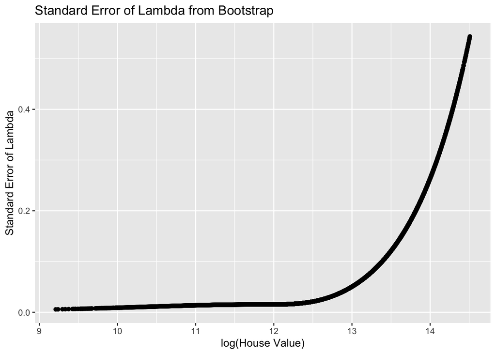

```r
# create a dataframe with all unique values of log.house.value
dp = data.frame(log.house.value=unique(dc$log.house.value))
dp <- dp %>% drop_na()

# bootstrap
set.seed(661) # so that each time knitting I get the same results to report
J <- 100

nvals <- nrow(dp)

## Create a data frame to keep track of the coefficients and predictions
boot.results = data.frame(j=(rep(1:J, each = nvals)),
                          coef=NA,
                          log.lambdahat=NA,
                          log.house.value = rep(dp$log.house.value, times = J))

for (j in 1:J){

  ## pick rows to use for the bootstrap sample
  rows = sample(x=1:nrow(dc), size = nrow(dc), replace = T)

  ## create bootstrap sample
  db = dc[rows,]

  ## fit the model
  m1 = glm(lev2 ~ log.house.value, data = db, family='poisson')

  ## record coefficients and predictions
  boot.results$coef[boot.results$j == j] = coef(m1)[2]
  boot.results$log.lambdahat[boot.results$j == j] =
    predict(m1, newdata = dp, type = 'link')

}

# we estimated log, now we convert them back to lambdahaat
boot.results$lambdahat <- exp(boot.results$log.lambdahat)

dbb <- boot.results %>%
  group_by(log.house.value) %>%
  summarize(log.house.value = mean(log.house.value),
            bootstrap.lambdahat = mean(lambdahat),
            bootstrap.se = sd(lambdahat))

g61 <- ggplot(dbb, aes(x = log.house.value, y = bootstrap.se)) +
  geom_point() +
  labs(title = "Standard Error of Lambda from Bootstrap",
       x = "log(House Value)",
       y = "Standard Error of Lambda")
g61
```

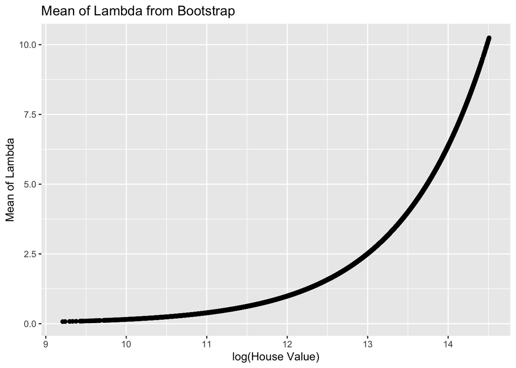

```r
g62 <- ggplot(dbb, aes(x = log.house.value, y = bootstrap.lambdahat)) +
  geom_point() +
  labs(title = "Mean of Lambda from Bootstrap",
       x = "log(House Value)",
       y = "Mean of Lambda")
g62
```

There are two main reasons for the discrepancies in terms of the standard errors of $\hat{\lambda}$ for different values of `log.house.value`.

First of all, we can see that both the standard error and the mean of $\hat{\lambda}$ increase as `log.house.value` increases. We know that the underlying parameter $\lambda$ is the mean of the Poisson distribution, and the variance of the Poisson distribution is equal to its mean. Therefore, the standard error of $\hat{\lambda}$ is proportional to the square root of the variance of the response variable, which also increases as `log.house.value` increases.

Secondly, by the central limit theorem, the standard error of $\hat{\lambda}$ is inversely proportional to the square root of the number of samples. Hence, for values of `log.house.value` with fewer observations, we would expect a larger standard error.

### 7. Compare s.e. with bootstrapped s.e.

Plot $\hat{\lambda} + 2 \, s.e.$ and $\hat{\lambda} - 2 \, s.e.$ along with the curve for $\hat{\lambda}$, and $\pm 2 \,s.e.$ that you get from using `predict(glm1, newdata = dc, type = 'response', se.fit = T)` from the Poisson (`glm1`), Quasipoisson (`glm2`) and Negative binomial (`glm3`) models. Compare the results.

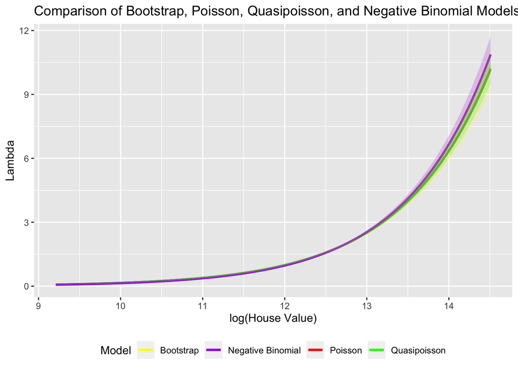

```r
# build glm1, glm2, and glm3
glm1 = glm(lev2 ~ log.house.value, data=dc, family='poisson')
glm2 = glm(lev2 ~ log.house.value, data=dc, family='quasipoisson')
glm3 = glm.nb(lev2 ~ log.house.value, data=dc)

# predict lambdahat and se from glm1, glm2, and glm3
dbb$poisson.lambdahat <-
  predict(glm1, newdata = dbb, type = 'response')
dbb$poisson.se <-
  predict(glm1, newdata = dbb, type = 'response', se.fit = T)$se.fit
dbb$quasipoisson.lambdahat <-
  predict(glm2, newdata = dbb, type = 'response')
dbb$quasipoisson.se <-
  predict(glm2, newdata = dbb, type = 'response', se.fit = T)$se.fit
dbb$negbin.lambdahat <-
  predict(glm3, newdata = dbb, type = 'response')
dbb$negbin.se <-
  predict(glm3, newdata = dbb, type = 'response', se.fit = T)$se.fit

# plot
g7 <- ggplot(dbb, aes(x = log.house.value)) +
  geom_line(aes(y = bootstrap.lambdahat, color = "Bootstrap"), linewidth = 1) +
  geom_line(aes(y = poisson.lambdahat, color = "Poisson"), linewidth = 1) +
  geom_line(aes(y = quasipoisson.lambdahat, color = "Quasipoisson"), linewidth = 1) +
  geom_line(aes(y = negbin.lambdahat, color = "Negative Binomial"), linewidth = 1) +
  geom_ribbon(aes(ymin = bootstrap.lambdahat - 2*bootstrap.se,
                  ymax = bootstrap.lambdahat + 2*bootstrap.se),
              fill = "yellow", alpha = 0.2) +
  geom_ribbon(aes(ymin = poisson.lambdahat - 2*poisson.se,
                  ymax = poisson.lambdahat + 2*poisson.se),
              fill = "red", alpha = 0.2) +
  geom_ribbon(aes(ymin = quasipoisson.lambdahat - 2*quasipoisson.se,
                  ymax = quasipoisson.lambdahat + 2*quasipoisson.se),
              fill = "green", alpha = 0.2) +
  geom_ribbon(aes(ymin = negbin.lambdahat - 2*negbin.se,
                  ymax = negbin.lambdahat + 2*negbin.se),
              fill = "purple", alpha = 0.2) +
  scale_color_manual(name = "Model",
                     values = c("Bootstrap" = "yellow",
                                "Poisson" = "red",
                                "Quasipoisson" = "green",
                                "Negative Binomial" = "purple")) +
  labs(title = "Comparison of Bootstrap, Poisson, Quasipoisson, and Negative Binomial Models",
       x = "log(House Value)",
       y = "Lambda") +
  theme(legend.position = "bottom")

g7
```

First, the bootstrap mean is very close to the Poisson model and Quasipoisson model for all values of `log.house.value`. The mean for negative binomial is not far for most values of `log.house.value`, but it is slightly higher for large values of `log.house.value`, as we can see from the right tail.

## Bootstrapping

Suppose that we obtain a bootstrap sample from a set of $n$ observations. We will now show that the probability that the $j$th observation is part of a bootstrap sample is 0.632 for large enough $n$.

### 8. 1st and 2nd observation are in the sample

What is the probability that the 1st bootstrap observation is *not* the $j$th observation from the original sample? The 2nd bootstrap observation?

The probability that the 1st bootstrap observation is not the $j$th observation is $\frac{n-1}{n}$, because there are $n-1$ other observations to choose from.

The probability that the 2nd bootstrap observation is not the $j$th observation is also $\frac{n-1}{n}$ for the same reason as the 1st observation. This is because each bootstrap sample is independent of each other.

### 9. jth observation is not in the sample

Argue that the probability that the $j$th observation is *not* in the bootstrap sample is $(1 - 1/n)^n$.

Since each element in the bootstrap sample is independent of each other, the joint probability that the $j$th observation is not any element of the bootstrap sample is the product of individual probabilities, which is $(1 - \frac{1}{n})^n$.

### 10. jth observation is in the sample

What is the probability that the $j$th observation *is* in the bootstrap sample? Find the limit of your answer as $n\rightarrow \infty$. Argue that for large enough $n$, the probability that the $j$th observation is in the bootstrap sample is around 0.632.

The event that the $j$th observation is in the bootstrap sample is the complement of the event that the $j$th observation is not in the bootstrap sample. Hence, this probability is equal to $1 - (1 - \frac{1}{n})^n$. As $n \to \infty$, this probability converges to $1 - e^{-1} \approx 0.632$.